# Tangle Lakes Analysis

## 1.0.0 First We will Look at the Shallow-Round Tangle Lake System. (Part 1)

Here Let’s take an initial look at the cleaned dataframe, and parse the large dataset to only the shallow-round data

```
##      Lake               Gear                Set              Lat
##  Length:1164        Length:1164        Min.   :  1.00   Min.   :63.02
##  Class :character   Class :character   1st Qu.: 28.00   1st Qu.:63.06
##  Mode  :character   Mode  :character   Median : 58.00   Median :63.08
##                                        Mean   : 65.22   Mean   :63.10
##                                        3rd Qu.: 95.00   3rd Qu.:63.14
##                                        Max.   :202.00   Max.   :63.15
##                                                         NA's   :2
##       Lon              Date                          Species
##  Min.   :-146.1   Min.   :2023-04-12 00:00:00.00   Length:1164
##  1st Qu.:-146.0   1st Qu.:2023-06-20 00:00:00.00   Class :character
##  Median :-146.0   Median :2024-04-10 00:00:00.00   Mode  :character
##  Mean   :-146.0   Mean   :2023-12-13 14:58:08.66
##  3rd Qu.:-146.0   3rd Qu.:2024-06-15 00:00:00.00
##  Max.   :-145.9   Max.   :2024-06-28 00:00:00.00
##  NA's   :2
##  Fork_length            Weight           Sex                Mark
##  Length:1164        Min.   :   0.0   Length:1164        Length:1164
##  Class :character   1st Qu.: 770.2   Class :character   Class :character
##  Mode  :character   Median :1290.0   Mode  :character   Mode  :character
##                     Mean   :1680.3
##                     3rd Qu.:2268.0
##                     Max.   :9072.0
##                     NA's   :446
##      Floy               PIT               Recap            cap_label
##  Length:1164        Length:1164        Length:1164        Length:1164
##  Class :character   Class :character   Class :character   Class :character
##  Mode  :character   Mode  :character   Mode  :character   Mode  :character
##
##
##
##
##   Fish_notes          event_num     lake_combined          stat
##  Length:1164        Min.   :1.000   Length:1164        Length:1164
##  Class :character   1st Qu.:2.000   Class :character   Class :character
##  Mode  :character   Median :3.000   Mode  :character   Mode  :character
##                     Mean   :2.832
##                     3rd Qu.:4.000
##                     Max.   :4.000
##
##    grouping
##  Length:1164
##  Class :character
##  Mode  :character
##
##
##
##
```

### 1.1 Evaluating Growth and Length Composition Analysis

#### 1.1.1 Visualization of ECDF with and Without Length-correction for 2024 (N2) Fish

```
## [1] "glimpse of filtered data for shallow-round"
```

```
##      Lake Gear Set      Lat       Lon       Date Species Fork_length Weight
## 1 Shallow  ANG  58 63.07093 -145.9740 2023-06-18      LT         519   1701
## 2   Round  OTH   7 63.05757 -145.9864 2023-06-10      LT         589     NA
## 3   Round  ANG  82 63.05783 -145.9896 2023-06-24      LT         374     NA
## 4   Round  ANG   2 63.05516 -145.9997 2023-06-10      LT         350     NA
## 5   Round  ANG   6 63.05591 -145.9856 2023-06-10      LT         353     NA
## 6   Round  ANG   4 63.05767 -145.9813 2023-06-10      LT         371     NA
##    Sex                      Mark  Floy  PIT Recap cap_label
## 1 <NA> Gray Floy 18517; PIT 12EC 18517 12EC  <NA>        n1
## 2 <NA>           Gray Floy 18007 18007 <NA>  <NA>        n1
## 3 <NA>           Gray Floy 18259 18259 <NA>  <NA>        n1
## 4 <NA>           Gray Floy 18002 18002 <NA>  <NA>        n1
## 5 <NA>           Gray Floy 18006 18006 <NA>  <NA>        n1
## 6 <NA>           Gray Floy 18004 18004 <NA>  <NA>        n1
##                                          Fish_notes event_num lake_combined
## 1                 Chonky fish!;  Gear = Baited Lure         2 Shallow_Round
## 2 Did not PIT Tag;  Gear = Baited Hookless Jug Line         2 Shallow_Round
## 3              Did not PIT Tag;  Gear = Baited Lure         2 Shallow_Round
## 4            Did not PIT Tag;  Gear = Unbaited Lure         2 Shallow_Round
## 5            Did not PIT Tag;  Gear = Unbaited Lure         2 Shallow_Round
## 6            Did not PIT Tag;  Gear = Unbaited Lure         2 Shallow_Round
##   stat grouping corrected_length class year_cap year_recap
## 1   n1       n1              519  <NA>       NA         NA
## 2   n1       n1              589  <NA>       NA         NA
## 3   n1       n1              374  <NA>       NA         NA
## 4   n1       n1              350  <NA>       NA         NA
## 5   n1       n1              353  <NA>       NA         NA
## 6   n1       n1              371  <NA>       NA         NA
```

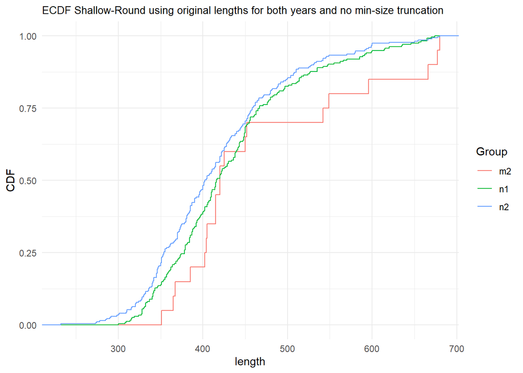

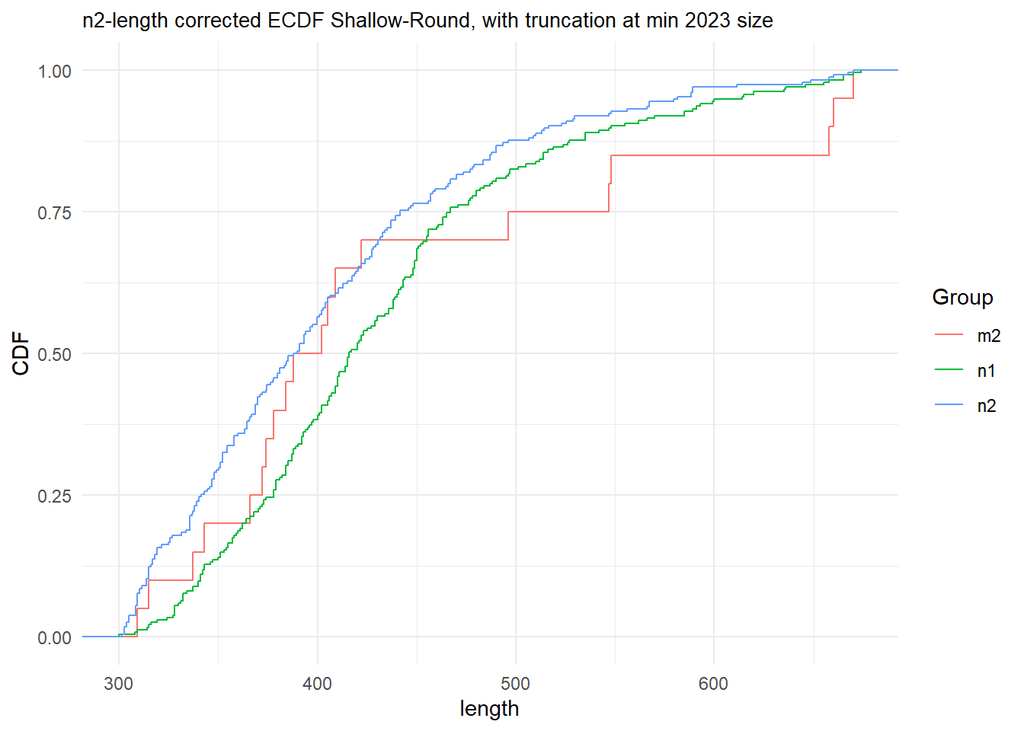

As we can see above, in the first plot we observe the cumulitive distribution function of length in 2023 (n1) and 2024 (n2) that is not corrected for growth. In the second plot, we observe the cdf of length in 2023 (n1) and 2024 (n2*), in which 2024 lengths are corrected to what they “would have been” in 2023. This correction assumes that the population is NOT at some kind of equilibrium, and therefore shifts the entire n2 distribution to the left as seen above.

#### 1.1.2 K-S tests with and without length-correction

```
## [1] "KS-test results without length correction:"
```

```
##            lake ks_test statistic    p_value reject_null
## 1 Shallow-Round  M vs R 0.1957447 0.41107516       FALSE
## 2 Shallow-Round  C vs R 0.2944238 0.06053772       FALSE
## 3 Shallow-Round  M vs C 0.1026339 0.14232694       FALSE
```

```
## [1] "KS test results with length correction: "
```

```
##            lake ks_test statistic      p_value reject_null
## 1 Shallow-Round  M vs R 0.2074468 3.403055e-01       FALSE
## 2 Shallow-Round  C vs R 0.1846154 4.798337e-01       FALSE
## 3 Shallow-Round  M vs C 0.2061829 9.367004e-05        TRUE
```

As we can see, the KS-test cites that the m (n1) and c(n2) events come from different distributions when the n2 event is corrected for growth, but not when the n2 event is not corrected for growth.

Ultimately, without correcting for growth, results from the KS test indicate no stratification is required by length.

#### 1.1.3 Length Composition Analysis Without growth correction

Below we will assume that the population is in equilibrium, as is suggested by the similar ECDF of fish caught in round/shallow tangle-lake in 2023 and 2024. We will move forward with an estimate of length composition analysis under equilibrium pop dynamics.

```
## [1] "Let's visualize the non-binned continuous length distribution in a few ways"
```

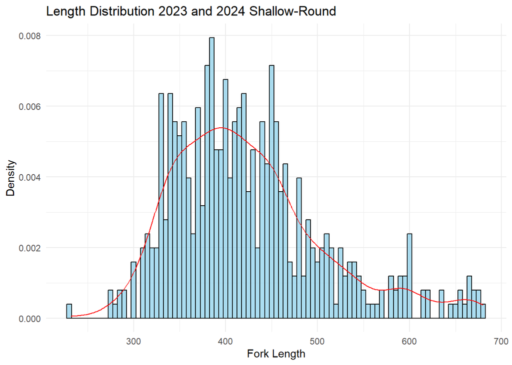

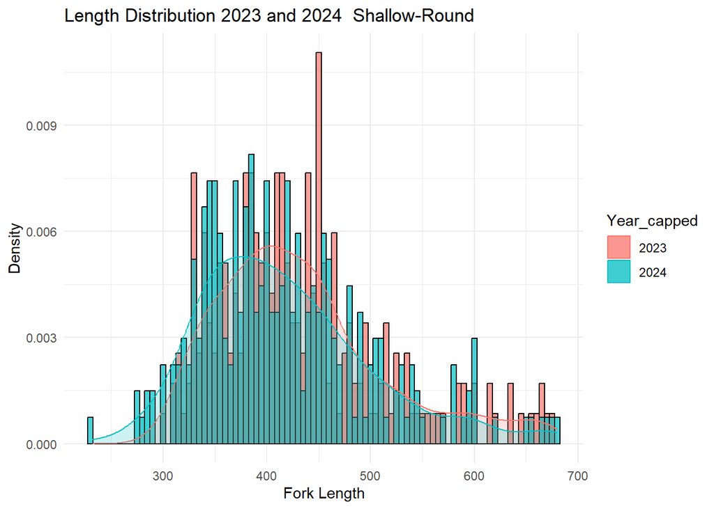

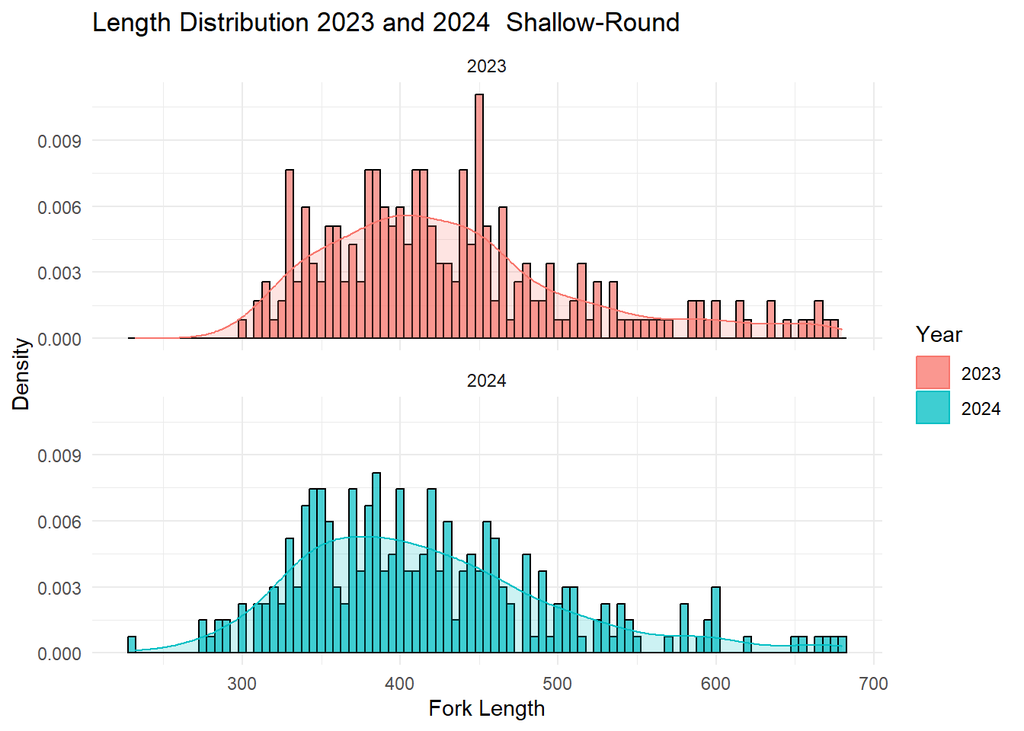

```
## [1] 231
##  [1] 231 256 281 306 331 356 381 406 431 456 481 506 531 556 581 606 631 656 Inf
```

```
## [1] "Now we have binned the shallow-round data, let's take a look at the stats for both years"
```

Binned Length Stats Shallow-Round 2023 + 2024

| bin | count | proportion | variance |
| --- | --- | --- | --- |
| 231-255 | 1 | 0.0019841 | 0.0000039 |
| 256-280 | 3 | 0.0059524 | 0.0000118 |
| 281-305 | 8 | 0.0158730 | 0.0000311 |
| 306-330 | 30 | 0.0595238 | 0.0001113 |
| 331-355 | 68 | 0.1349206 | 0.0002320 |
| 356-380 | 54 | 0.1071429 | 0.0001902 |
| 381-405 | 73 | 0.1448413 | 0.0002462 |
| 406-430 | 67 | 0.1329365 | 0.0002292 |
| 431-455 | 59 | 0.1170635 | 0.0002055 |
| 456-480 | 40 | 0.0793651 | 0.0001453 |
| 481-505 | 25 | 0.0496032 | 0.0000937 |
| 506-530 | 20 | 0.0396825 | 0.0000758 |
| 531-555 | 16 | 0.0317460 | 0.0000611 |
| 556-580 | 7 | 0.0138889 | 0.0000272 |
| 581-605 | 14 | 0.0277778 | 0.0000537 |
| 606-630 | 4 | 0.0079365 | 0.0000157 |
| 631-655 | 6 | 0.0119048 | 0.0000234 |
| 656-max | 9 | 0.0178571 | 0.0000349 |

```
## [1] "Now let's look at the length-distribution binned for 2023"
```

Binned Length Stats Shallow-Round 2023

| bin | count | proportion | variance |
| --- | --- | --- | --- |
| 231-255 | 0 | 0.0000000 | 0.0000000 |
| 256-280 | 0 | 0.0000000 | 0.0000000 |
| 281-305 | 1 | 0.0042553 | 0.0000181 |
| 306-330 | 13 | 0.0553191 | 0.0002233 |
| 331-355 | 25 | 0.1063830 | 0.0004063 |
| 356-380 | 26 | 0.1106383 | 0.0004205 |
| 381-405 | 33 | 0.1404255 | 0.0005158 |
| 406-430 | 35 | 0.1489362 | 0.0005417 |
| 431-455 | 33 | 0.1404255 | 0.0005158 |
| 456-480 | 19 | 0.0808511 | 0.0003176 |
| 481-505 | 11 | 0.0468085 | 0.0001907 |
| 506-530 | 10 | 0.0425532 | 0.0001741 |
| 531-555 | 7 | 0.0297872 | 0.0001235 |
| 556-580 | 3 | 0.0127660 | 0.0000539 |
| 581-605 | 7 | 0.0297872 | 0.0001235 |
| 606-630 | 3 | 0.0127660 | 0.0000539 |
| 631-655 | 4 | 0.0170213 | 0.0000715 |
| 656-max | 5 | 0.0212766 | 0.0000890 |

```
## [1] "Now let's look at the length-distribution binned for 2024"
```

Binned Length Stats Shallow-Round 2024

| bin | count | proportion | variance |
| --- | --- | --- | --- |
| 231-255 | 1 | 0.0037175 | 0.0000138 |
| 256-280 | 3 | 0.0111524 | 0.0000411 |
| 281-305 | 7 | 0.0260223 | 0.0000946 |
| 306-330 | 17 | 0.0631970 | 0.0002209 |
| 331-355 | 43 | 0.1598513 | 0.0005011 |
| 356-380 | 28 | 0.1040892 | 0.0003480 |
| 381-405 | 40 | 0.1486989 | 0.0004723 |
| 406-430 | 32 | 0.1189591 | 0.0003911 |
| 431-455 | 26 | 0.0966543 | 0.0003258 |
| 456-480 | 21 | 0.0780669 | 0.0002686 |
| 481-505 | 14 | 0.0520446 | 0.0001841 |
| 506-530 | 10 | 0.0371747 | 0.0001336 |
| 531-555 | 9 | 0.0334572 | 0.0001207 |
| 556-580 | 4 | 0.0148699 | 0.0000547 |
| 581-605 | 7 | 0.0260223 | 0.0000946 |
| 606-630 | 1 | 0.0037175 | 0.0000138 |
| 631-655 | 2 | 0.0074349 | 0.0000275 |
| 656-max | 4 | 0.0148699 | 0.0000547 |

```
## [1] "Let's visualize the binned length distributions"
```

```
## [1] "Pooled Length Distribution 2023 and 2024"
```

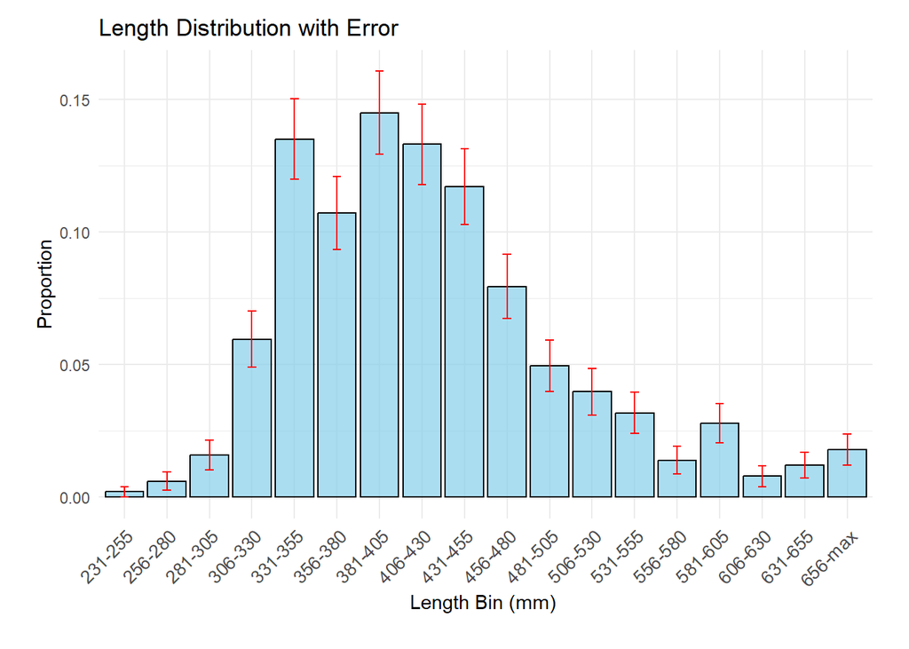

```
## [1] "Length Distribution 2023 only"
```

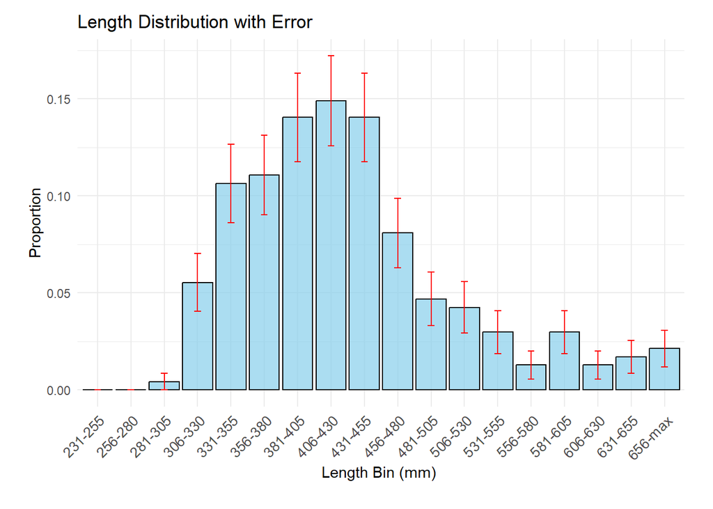

```
## [1] "Length Distribution 2024 only"
```

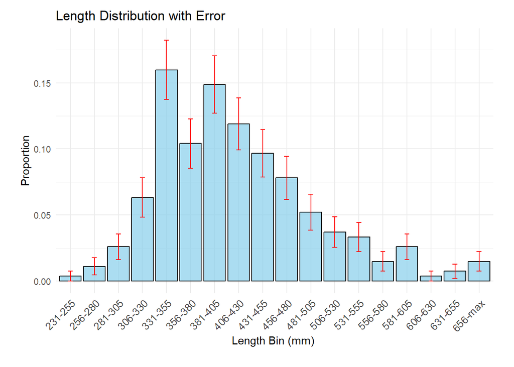

#### 1.1.4 Length-By-Weight Analysis

Let’s take a look at the length-by weight analysis using the LBV model

```
##
## Call:
## lm(formula = log(Weight) ~ log(as.numeric(Fork_length)), data = dataz)
##
## Residuals:
##      Min       1Q   Median       3Q      Max
## -0.95041 -0.09293 -0.01157  0.09922  1.04807
##
## Coefficients:
##                               Estimate Std. Error t value Pr(>|t|)
## (Intercept)                  -13.77932    0.45423  -30.34   <2e-16 ***
## log(as.numeric(Fork_length))   3.40408    0.07486   45.48   <2e-16 ***
## ---
## Signif. codes:  0 '***' 0.001 '**' 0.01 '*' 0.05 '.' 0.1 ' ' 1
##
## Residual standard error: 0.273 on 378 degrees of freedom
##   (124 observations deleted due to missingness)
## Multiple R-squared:  0.8455, Adjusted R-squared:  0.8451
## F-statistic:  2068 on 1 and 378 DF,  p-value: < 2.2e-16
```

```
## [1] "Sigma:"
```

```
## [1] 0.2729856
```

```
## [1] "alpha:"
```

```
## [1] -13.77932
```

```
## [1] "beta:"
```

```
## [1] 3.404077
```

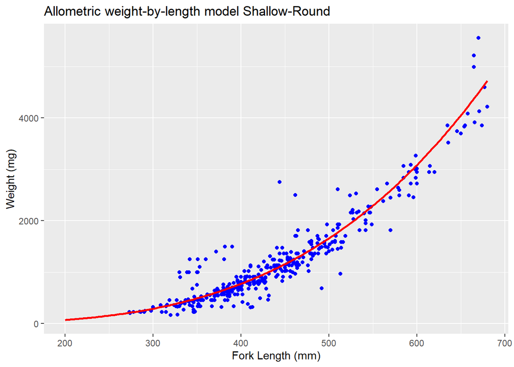

#### 1.1.5 What if we used the length-corrected data? Length composition analysis with length-corrected data

```
## [1] "Let's visualize the non-binned continuous length distribution in a few ways"
```

```
## [1] "if we look at both years overlayed, we can see that with the correction the 2024 histogram has a maximum density at a much lower fork length when we correct 2024 lengths for growth"
```

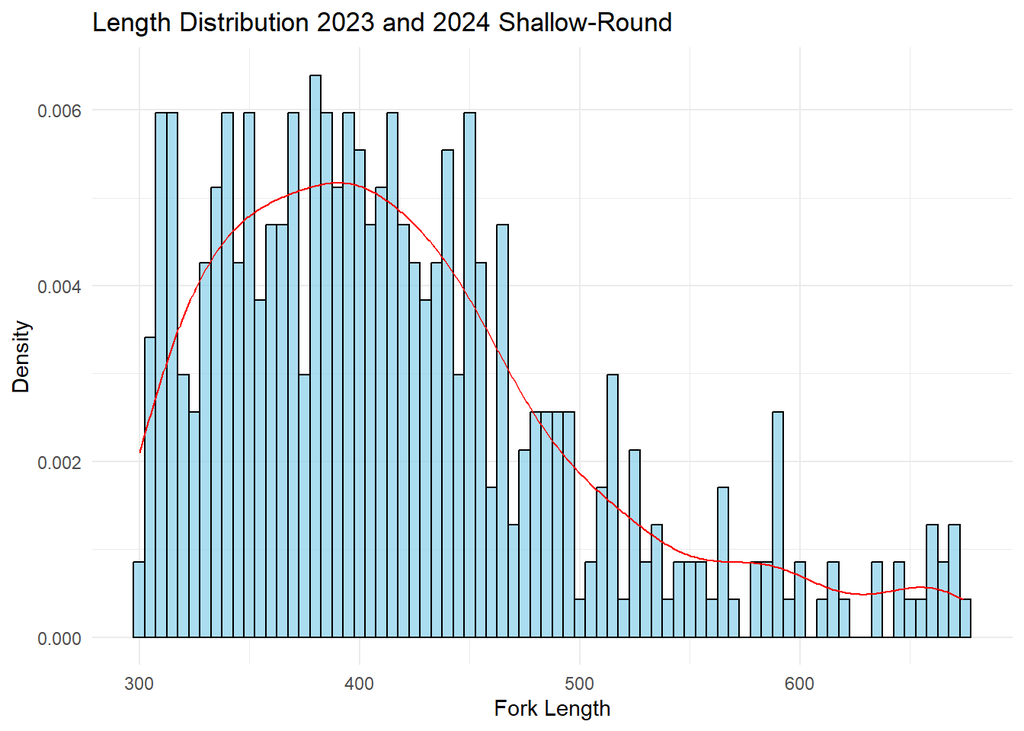

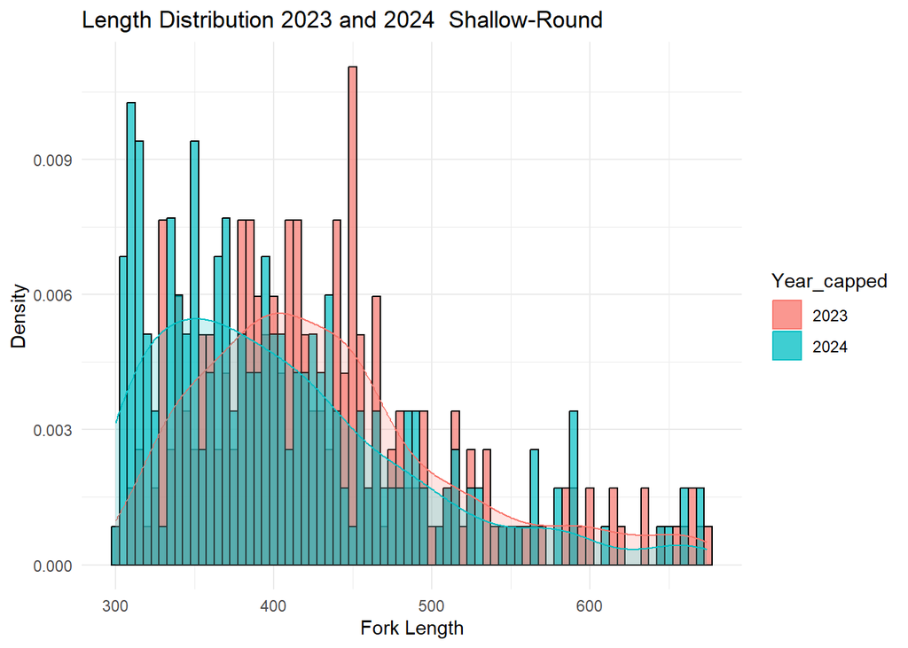

[figure not shown]

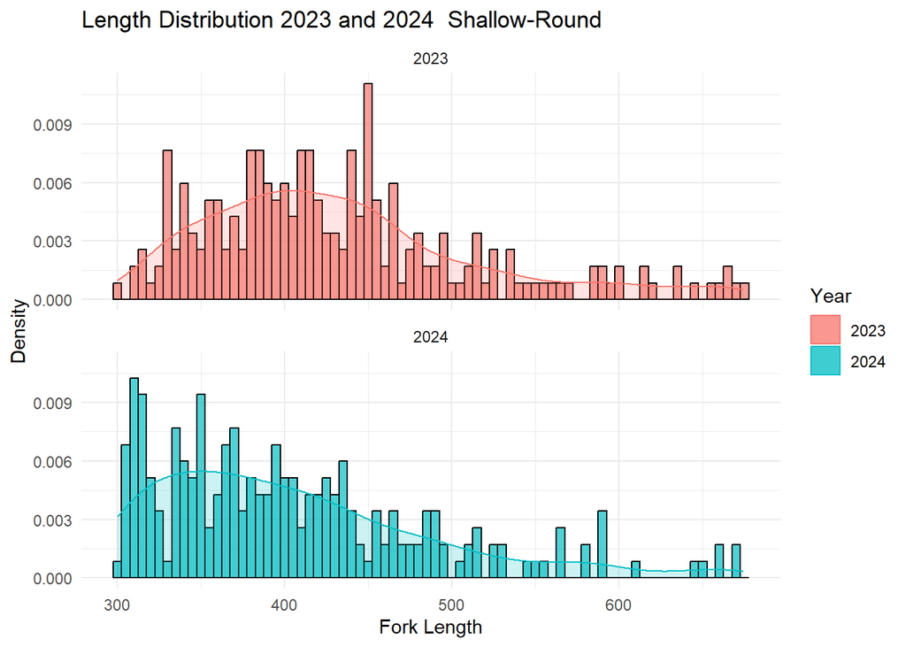

```
## [1] 299
##  [1] 299 324 349 374 399 424 449 474 499 524 549 574 599 624 649 674 Inf
```

```
## [1] "Let's visualize the binned length distributions"
```

```
## [1] "Pooled Length Distribution 2023 and 2024"
```

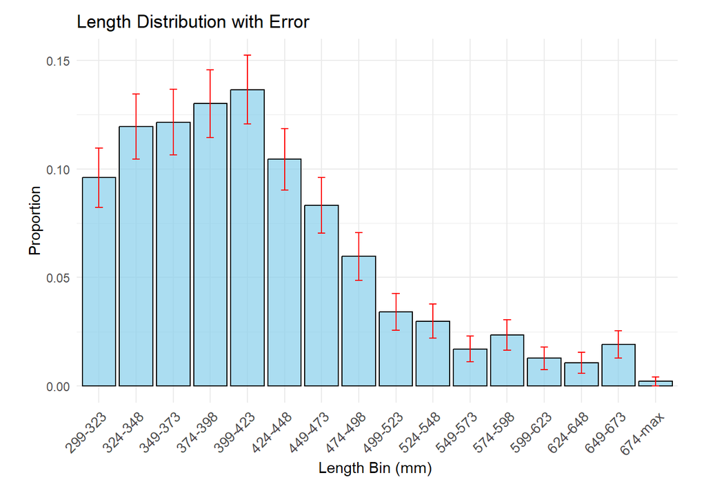

```
## [1] "Length Distribution 2023 only"
```

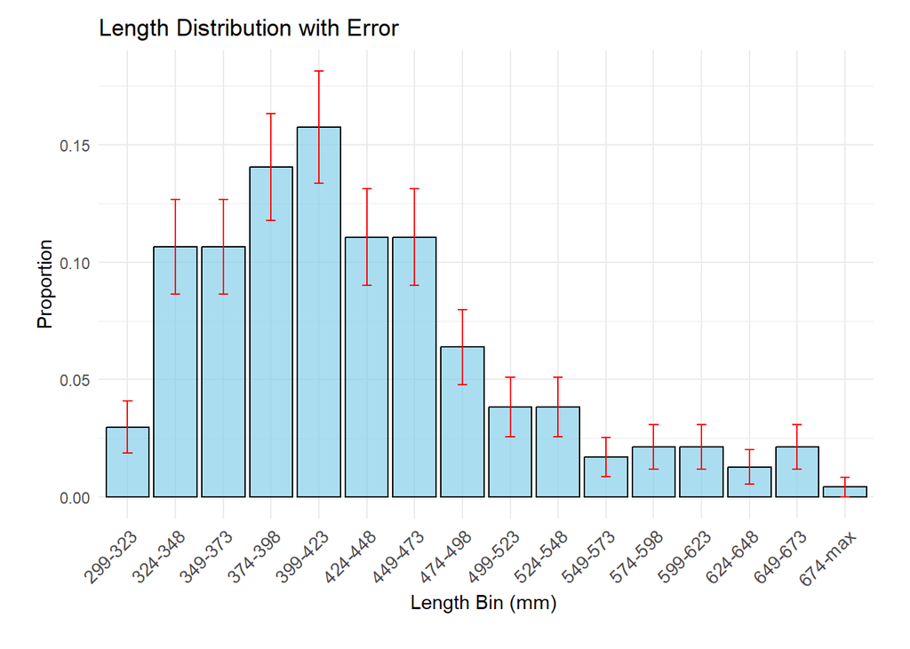

```
## [1] "Length Distribution 2024 only"
```

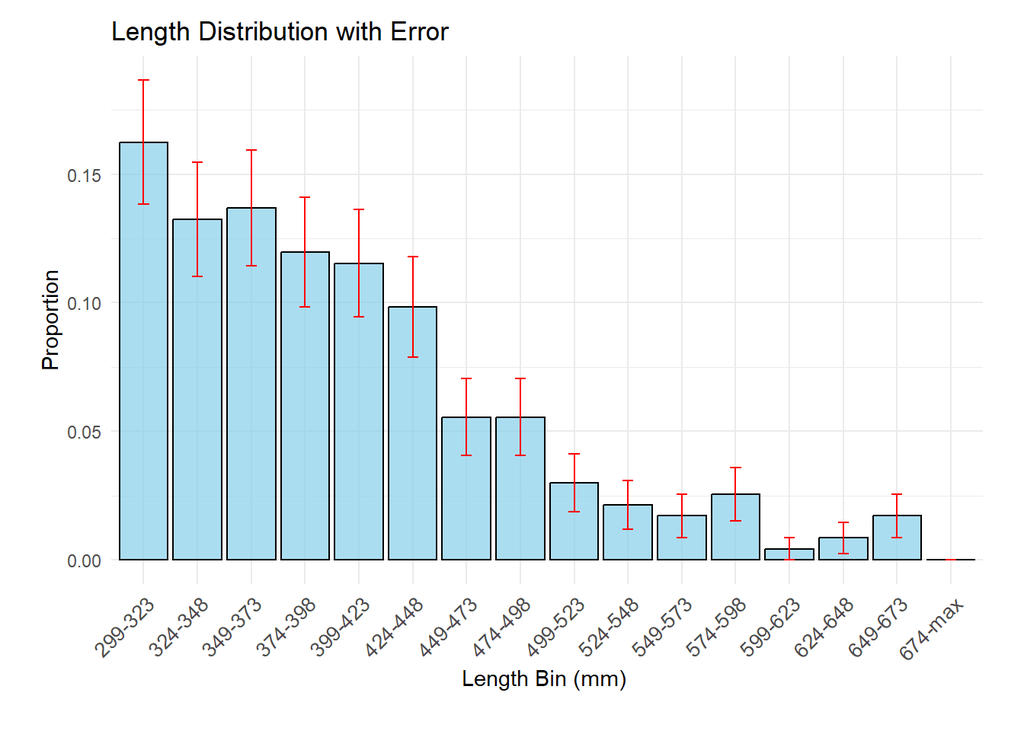

When we truncate the distribution, we get a right skew in our length-composition that does not reflect the true catchability.

## 1.2 Estimating Population Size

#### 1.2.1 Consistency Tests for the Peterson Estimator

```
## MIXING TEST
## H0: Movement probabilities from stratum i to stratum j are the same among sections (all theta_ij = theta_j)
##
##    1 2 3 not recaptured
## 1 14 0 0            143
## 2  0 0 0             28
## 3  0 0 4             46
##
##  X-squared:  NaN   df:  6   p-val:  NaN
##
## EQUAL PROPORTIONS TEST (SPAS terminology)
## H0: Marked to unmarked ratio among recapture strata is constant (Sum_i a_i*theta_ij/U_j = k)
##
##              1  2  3
## recaptured  14  0  4
## unmarked   149 12 55
##
##  X-squared:  1.253769   df:  2   p-val:  0.5342536
##
## COMPLETE MIXING TEST (SPAS terminology)
## H0: Probability of re-sighting a released animal is independent of its stratum of origin (Sum_i theta_ij*p_j = d)
##
##                  1  2  3
## recaptured      14  0  4
## not recaptured 143 28 46
##
##  X-squared:  2.681852   df:  2   p-val:  0.2616034
##
```

As we can see above, at least one of the null hypotheses was not rejected, so we can assume consistency of the peterson estimator.

#### 1.2.2 Population Estimation

We will do a population estimation. We use the truncated dataset to correct for 2024 fish that were possible to catch in 2023. We will perform this estimate both including the two fish that moved from lower to shallow, and not including them.

```
## [1] "Petersen estimate for population size of Shallow-round lake with the 2 fish that moved"
```

```
##      pop       se      var norm_95_low norm_95_high
## 1 2749.5 587.9463 345680.9    1597.125     3901.875
```

```
## [1] "Petersen estimate for population size of Shallow-round lake without the 2 fish that moved"
```

```
##        pop       se      var norm_95_low norm_95_high
## 1 3028.889 685.6618 470132.2    1684.992     4372.786
```

Because we have such a small number of recaps in round/shallow, two fish makes a big difference.

# 2.0.0 Now We will Look at the Lower Tangle Lake System. (Part 2)

We already determined in the growth_correction file that we can use pooled data to represent growth, and that there is not significant growth within years (there is significant growth within years, but only if we only remove negative outliers and there are very small sample sizes in this case.)

Below I will use the corrected lengths for N2 using the pooled regressions.

### 2.1 Evaluating Growth and Length Composition Analysis

#### 2.1.1 Visualization of ECDF with and Without Length-correction for 2024 (N2) Fish

```
## [1] "first let's look at the ecdf without truncating the distribution or correcting for length-changes"
```

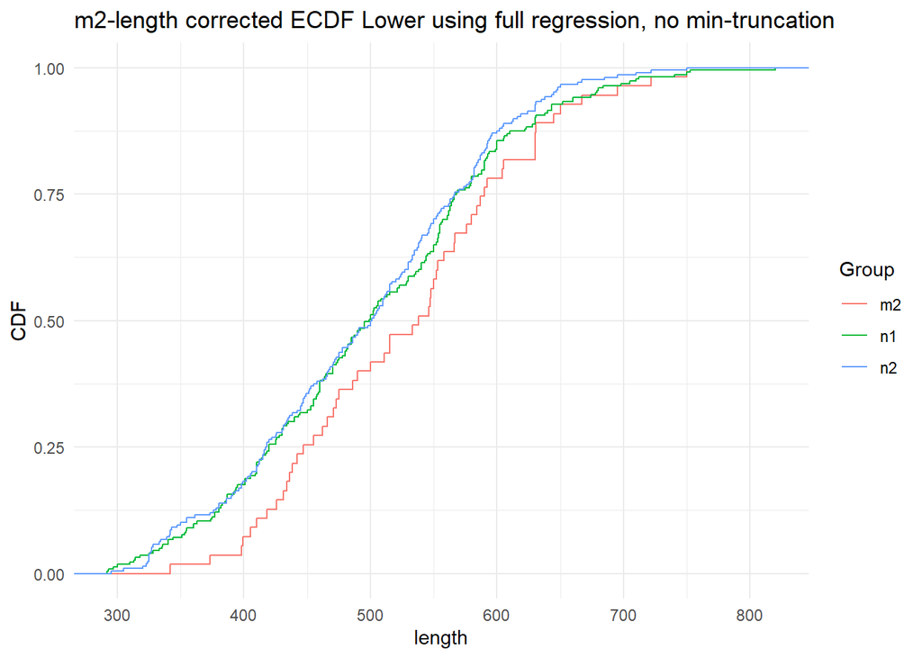

```
## [1] "Now let's truncate to the minimum captured size in event 1, and with corrected lengths for n2"
```

[figure not shown]

#### 2.1.2 K-S tests with and without length-correction

```
## [1] "KS-test results without length correction:"
```

```
##    lake ks_test  statistic   p_value reject_null
## 1 Lower  M vs R 0.14154097 0.3397493       FALSE
## 2 Lower  C vs R 0.16398601 0.1925886       FALSE
## 3 Lower  M vs C 0.05775699 0.8653800       FALSE
```

```
## [1] "KS test results with length correction: "
```

```
##    lake ks_test  statistic   p_value reject_null
## 1 Lower  M vs R 0.05756217 0.9985827       FALSE
## 2 Lower  C vs R 0.11168831 0.6576011       FALSE
## 3 Lower  M vs C 0.09622952 0.2888790       FALSE
```

Here, no matter whether we decide to truncate the data and correct for length changes or not, we see no evidence for the need to stratify by length. or to exclude one event.Therefore, we will continue with the analyses with data from both events.

#### 2.1.3 Length Composition Analysis Without growth correction

```
## [1] "Let's visualize the non-binned continuous length distribution in a few ways"
```

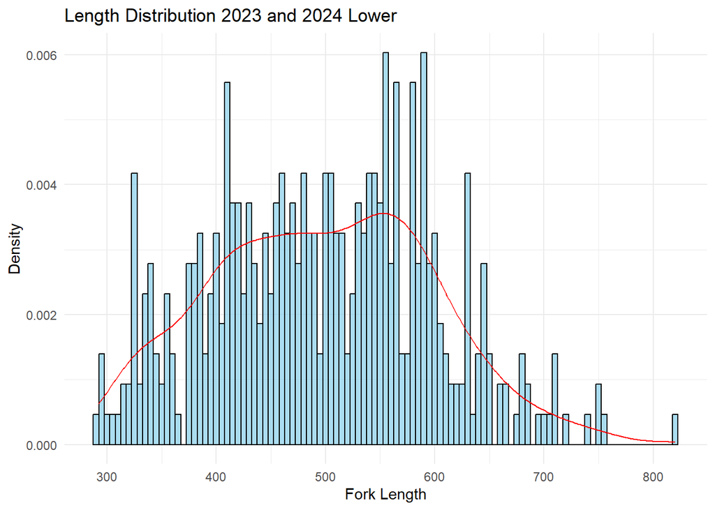

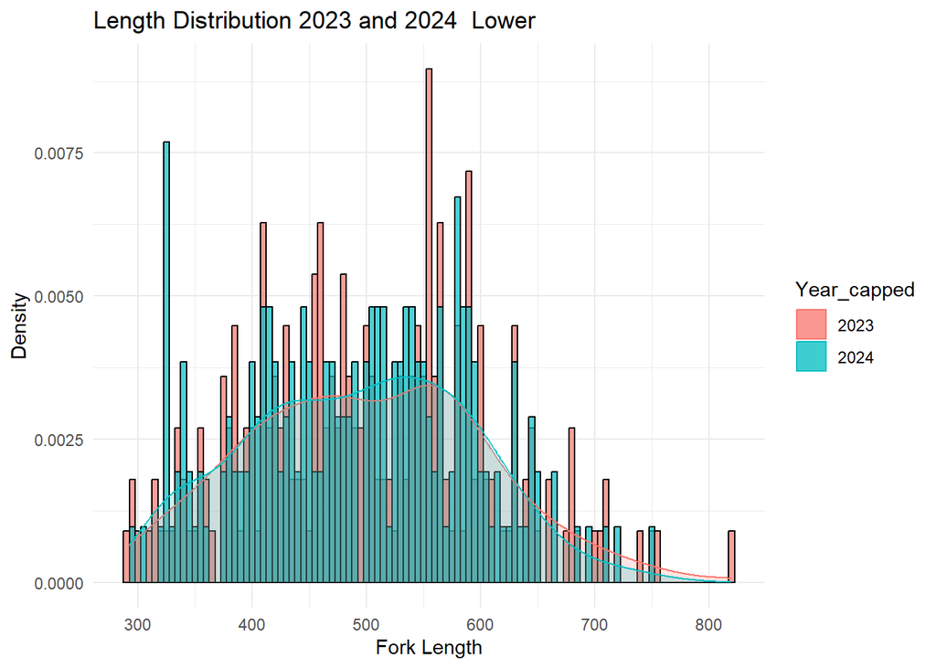

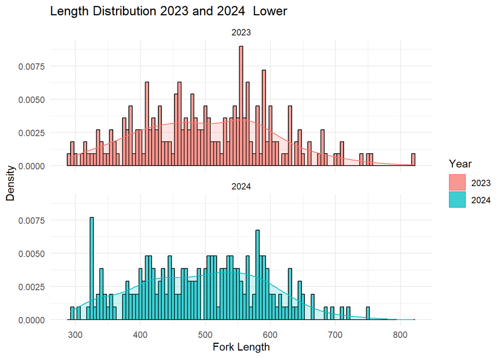

```
## [1] 291
##  [1] 291 316 341 366 391 416 441 466 491 516 541 566 591 616 641 666 691 716 741
## [20] 766 791 816 Inf
```

```
## [1] "Now we have binned the lower lake data, let's take a look at the stats for both years"
```

Binned Length Stats Lower 2023 + 2024

| bin | count | proportion | variance |
| --- | --- | --- | --- |
| 291-315 | 9 | 0.0208817 | 0.0000475 |
| 316-340 | 21 | 0.0487239 | 0.0001078 |
| 341-365 | 17 | 0.0394432 | 0.0000881 |
| 366-390 | 20 | 0.0464037 | 0.0001029 |
| 391-415 | 34 | 0.0788863 | 0.0001690 |
| 416-440 | 34 | 0.0788863 | 0.0001690 |
| 441-465 | 34 | 0.0788863 | 0.0001690 |
| 466-490 | 37 | 0.0858469 | 0.0001825 |
| 491-515 | 37 | 0.0858469 | 0.0001825 |
| 516-540 | 32 | 0.0742459 | 0.0001598 |
| 541-565 | 45 | 0.1044084 | 0.0002175 |
| 566-590 | 36 | 0.0835267 | 0.0001780 |
| 591-615 | 26 | 0.0603248 | 0.0001318 |
| 616-640 | 18 | 0.0417633 | 0.0000931 |
| 641-665 | 12 | 0.0278422 | 0.0000629 |
| 666-690 | 7 | 0.0162413 | 0.0000372 |
| 691-715 | 6 | 0.0139211 | 0.0000319 |
| 716-740 | 2 | 0.0046404 | 0.0000107 |
| 741-765 | 3 | 0.0069606 | 0.0000161 |
| 766-790 | 0 | 0.0000000 | 0.0000000 |
| 791-815 | 0 | 0.0000000 | 0.0000000 |
| 816-max | 1 | 0.0023202 | 0.0000054 |

```
## [1] "Let's look at just 2023 for lower lake"
```

Binned Length Stats Lower 2023

| bin | count | proportion | variance |
| --- | --- | --- | --- |
| 291-315 | 7 | 0.0313901 | 0.0001370 |
| 316-340 | 8 | 0.0358744 | 0.0001558 |
| 341-365 | 8 | 0.0358744 | 0.0001558 |
| 366-390 | 12 | 0.0538117 | 0.0002294 |
| 391-415 | 17 | 0.0762332 | 0.0003172 |
| 416-440 | 17 | 0.0762332 | 0.0003172 |
| 441-465 | 19 | 0.0852018 | 0.0003511 |
| 466-490 | 19 | 0.0852018 | 0.0003511 |
| 491-515 | 17 | 0.0762332 | 0.0003172 |
| 516-540 | 13 | 0.0582960 | 0.0002473 |
| 541-565 | 28 | 0.1255605 | 0.0004946 |
| 566-590 | 17 | 0.0762332 | 0.0003172 |
| 591-615 | 13 | 0.0582960 | 0.0002473 |
| 616-640 | 9 | 0.0403587 | 0.0001745 |
| 641-665 | 6 | 0.0269058 | 0.0001179 |
| 666-690 | 5 | 0.0224215 | 0.0000987 |
| 691-715 | 4 | 0.0179372 | 0.0000793 |
| 716-740 | 1 | 0.0044843 | 0.0000201 |
| 741-765 | 2 | 0.0089686 | 0.0000400 |
| 766-790 | 0 | 0.0000000 | 0.0000000 |
| 791-815 | 0 | 0.0000000 | 0.0000000 |
| 816-max | 1 | 0.0044843 | 0.0000201 |

```
## [1] "Let's look at just 2024 for lower lake"
```

Binned Length Stats Lower 2024

| bin | count | proportion | variance |
| --- | --- | --- | --- |
| 291-315 | 2 | 0.0096154 | 0.0000460 |
| 316-340 | 13 | 0.0625000 | 0.0002831 |
| 341-365 | 9 | 0.0432692 | 0.0002000 |
| 366-390 | 8 | 0.0384615 | 0.0001787 |
| 391-415 | 17 | 0.0817308 | 0.0003626 |
| 416-440 | 17 | 0.0817308 | 0.0003626 |
| 441-465 | 15 | 0.0721154 | 0.0003233 |
| 466-490 | 18 | 0.0865385 | 0.0003819 |
| 491-515 | 20 | 0.0961538 | 0.0004198 |
| 516-540 | 19 | 0.0913462 | 0.0004010 |
| 541-565 | 17 | 0.0817308 | 0.0003626 |
| 566-590 | 19 | 0.0913462 | 0.0004010 |
| 591-615 | 13 | 0.0625000 | 0.0002831 |
| 616-640 | 9 | 0.0432692 | 0.0002000 |
| 641-665 | 6 | 0.0288462 | 0.0001353 |
| 666-690 | 2 | 0.0096154 | 0.0000460 |
| 691-715 | 2 | 0.0096154 | 0.0000460 |
| 716-740 | 1 | 0.0048077 | 0.0000231 |
| 741-765 | 1 | 0.0048077 | 0.0000231 |
| 766-790 | 0 | 0.0000000 | 0.0000000 |
| 791-815 | 0 | 0.0000000 | 0.0000000 |
| 816-max | 0 | 0.0000000 | 0.0000000 |

```
## [1] "Binned Length Distribution for 2023/2024 combined "
```

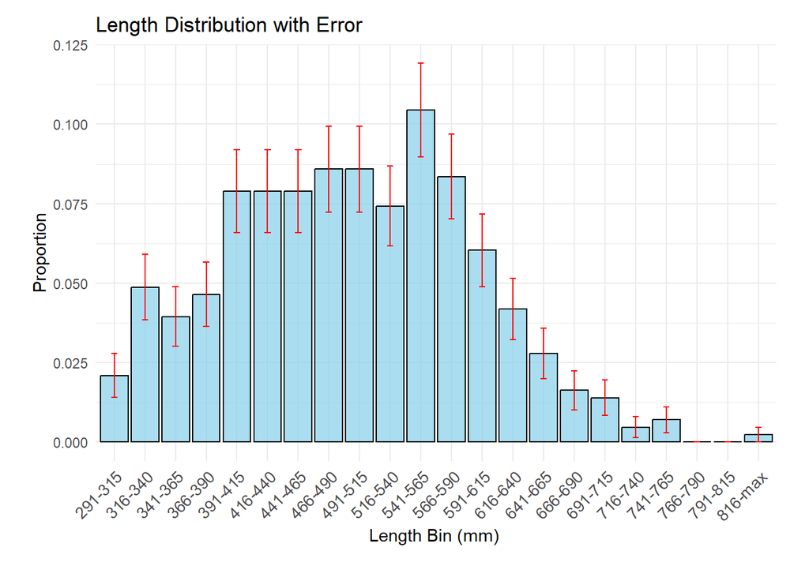

```
## [1] "Binned Length Distribution for 2023 only "
```

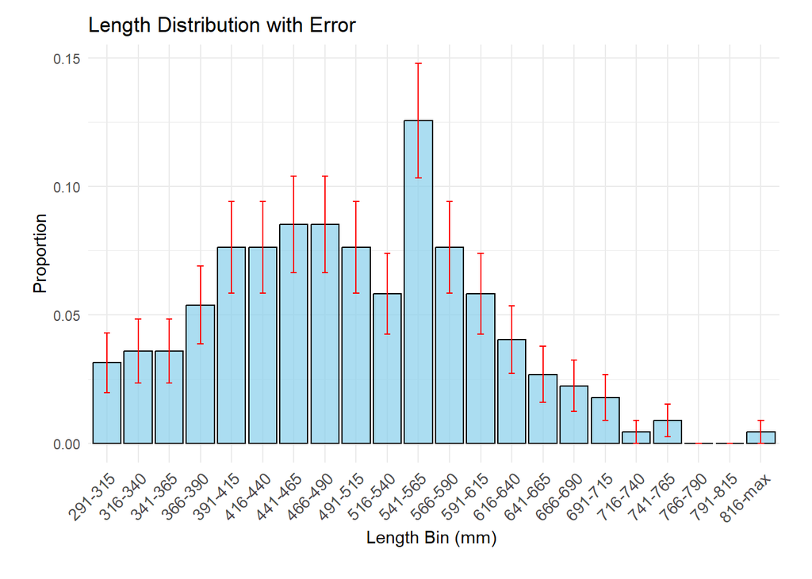

```
## [1] "Binned Length Distribution for 2024 only "
```

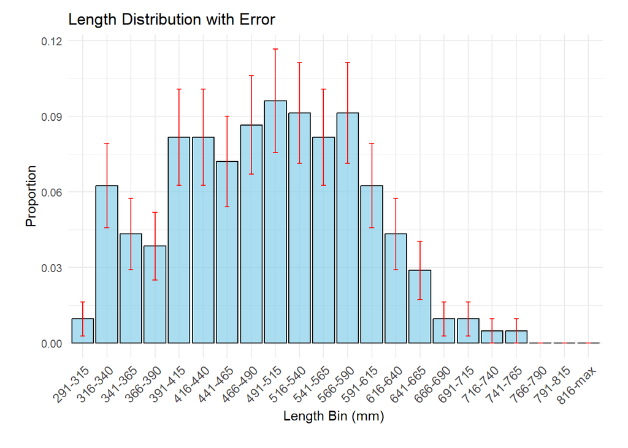

#### 2.1.4 Length-By-Weight Analysis

```r
#fit the LBV length-by weight relationship allometric model.

#aL^b is the model, we estimate parameters for a and b.

#this is the allometric weight-length model

#one poorly recorded weight of zero is fixed with this line.
wl.lin_lower <- lm_lw(data_full_Lower_n1n2%>%drop_na(Fork_length)%>%filter(Weight >0))


summary(wl.lin_lower)
```

```
##
## Call:
## lm(formula = log(Weight) ~ log(as.numeric(Fork_length)), data = dataz)
##
## Residuals:
##      Min       1Q   Median       3Q      Max
## -0.48430 -0.07054  0.00687  0.07758  0.46659
##
## Coefficients:
##                              Estimate Std. Error t value Pr(>|t|)
## (Intercept)                  -14.8290     0.3964  -37.41   <2e-16 ***
## log(as.numeric(Fork_length))   3.5719     0.0637   56.07   <2e-16 ***
## ---
## Signif. codes:  0 '***' 0.001 '**' 0.01 '*' 0.05 '.' 0.1 ' ' 1
##
## Residual standard error: 0.1568 on 182 degrees of freedom
## Multiple R-squared:  0.9453, Adjusted R-squared:  0.945
## F-statistic:  3144 on 1 and 182 DF,  p-value: < 2.2e-16
```

```r
# Remember, as a linear model the intercept is equal to ln(alpha) and the slope coefficient is equal to the beta parameter

#coef(wl.lin_lower)

# Finally lets save our parameter estimates
# Remember if we want the mean-unbiased estimate of the alpha parameter we need
#   to account for the lognormal correction when re-transforming

wl.lin.sigma_lower <- sigma(wl.lin_lower)
print("sigma: ")
```

```
## [1] "sigma: "
```

```r
wl.lin.sigma_lower
```

```
## [1] 0.1568186
```

```r
# There is an analytical solution for the error standard deviation

# ln(alpha)
wl.lin.ln_alpha_lower <- as.numeric(coef(wl.lin_lower)[1])

# alpha (mean-unbiased)# this is from the fish 622 course.
wl.lin.alpha_lower <-exp(wl.lin.ln_alpha_lower)*exp((wl.lin.sigma_lower^2)/2)
print("alpha:")
```

```
## [1] "alpha:"
```

```r
wl.lin.alpha_lower
```

```
## [1] 3.674406e-07
```

```r
# Beta
wl.lin.beta_lower <- as.numeric(coef(wl.lin_lower)[2])
print("beta: ")
```

```
## [1] "beta: "
```

```r
wl.lin.beta_lower
```

```
## [1] 3.571884
```

```r
print("Lets plot the model fit")
```

```
## [1] "Lets plot the model fit"
```

[figure not shown]

```r
plot_wl(data=data_full_Lower_n1n2, alpha=wl.lin.alpha_lower, beta=wl.lin.beta_lower)
```

It looks like the beta value for Lower tangle lake is a bit higher than shallow round tangle lake, but still hovering around 3.4/3.5.

#### 2.1.5 What if we used the length-corrected data? Length composition analysis with length-corrected data for Lower tangle lake

```
## [1] "Let's visualize the non-binned, length corrected continuous length distribution in a few ways"
```

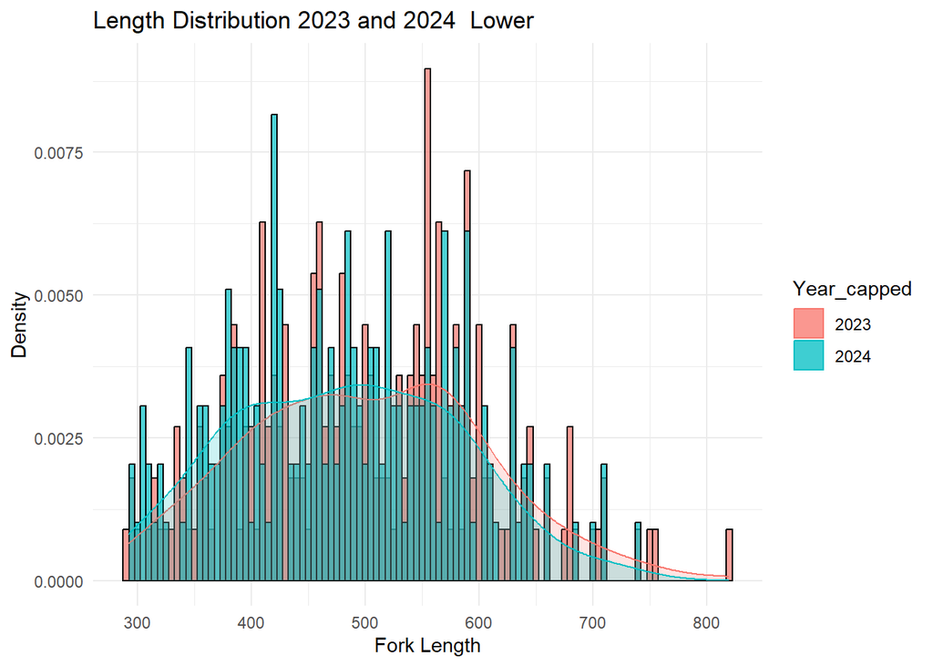

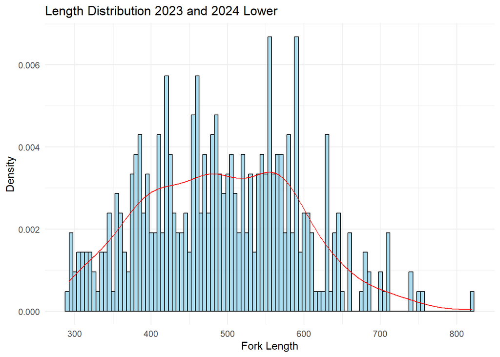

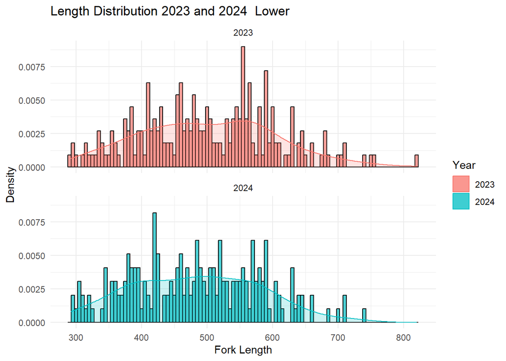

```
## [1] 291
##  [1] 291 316 341 366 391 416 441 466 491 516 541 566 591 616 641 666 691 716 741
## [20] 766 791 816 Inf
```

```
## [1] "Binned CORRECTED Length Distribution for 2023/2024 combined "
```

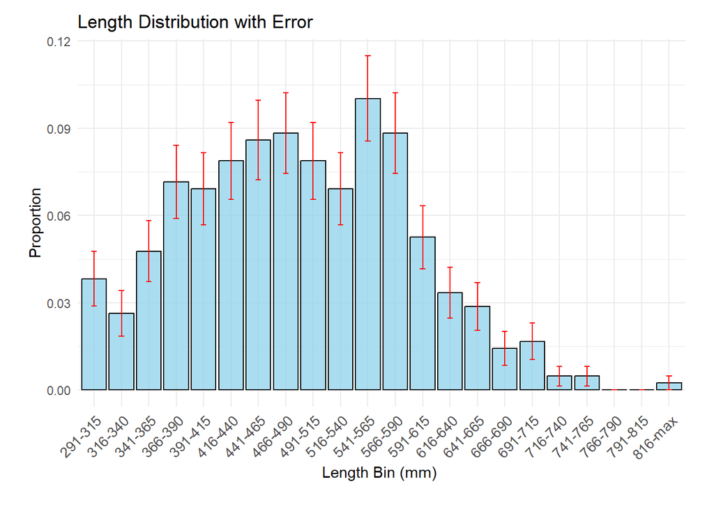

```
## [1] "Binned CORRECTED Length Distribution for 2023 only "
```

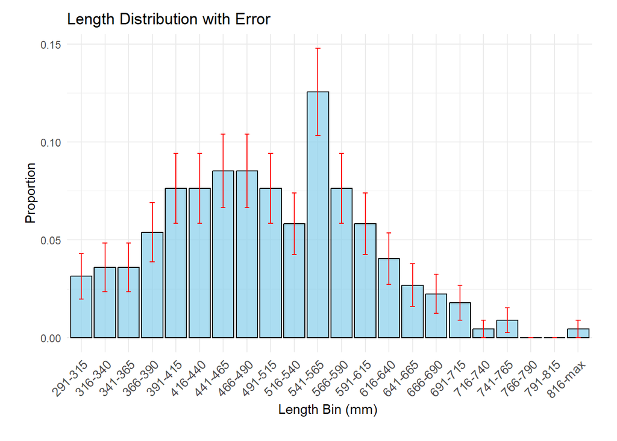

```
## [1] "Binned CORRECTED Length Distribution for 2024 only "
```

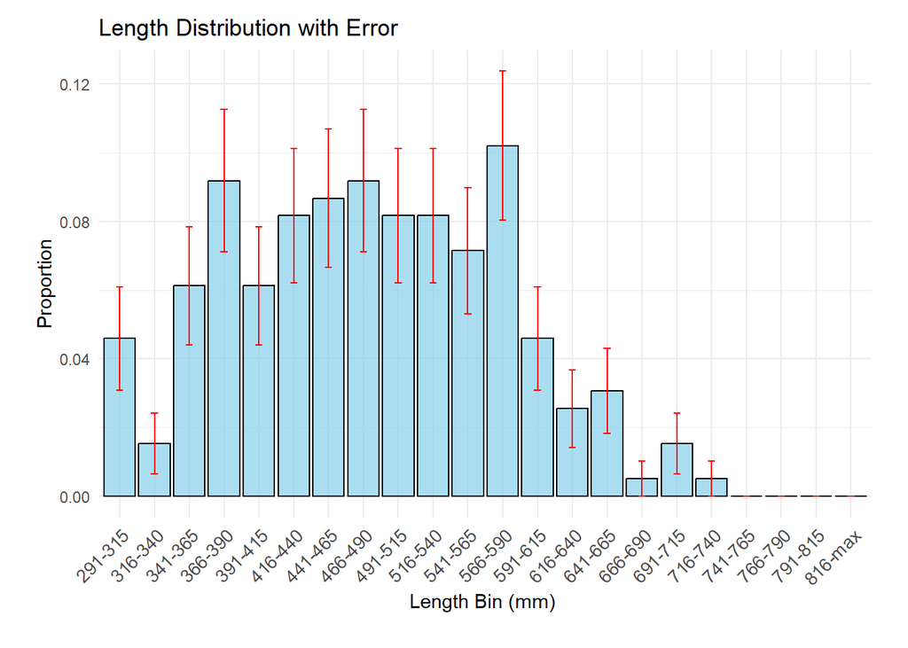

## 2.2 Estimating Population Size

#### 1.2.1 Consistency Tests for the Peterson Estimator

```
## MIXING TEST
## H0: Movement probabilities from stratum i to stratum j are the same among sections (all theta_ij = theta_j)
##
##   1  2 3 not recaptured
## 1 0  1 0              2
## 2 0 47 3            163
## 3 0  3 0              3
##
##  X-squared:  NaN   df:  6   p-val:  NaN
##
## EQUAL PROPORTIONS TEST (SPAS terminology)
## H0: Marked to unmarked ratio among recapture strata is constant (Sum_i a_i*theta_ij/U_j = k)
##
##            1   2 3
## recaptured 0  51 3
## unmarked   3 135 3
##
##  X-squared:  2.646992   df:  2   p-val:  0.2662031
##
## COMPLETE MIXING TEST (SPAS terminology)
## H0: Probability of re-sighting a released animal is independent of its stratum of origin (Sum_i theta_ij*p_j = d)
##
##                1   2 3
## recaptured     1  50 3
## not recaptured 2 163 3
##
##  X-squared:  2.364716   df:  2   p-val:  0.306555
##
```

As we can see above, the first test didn’t work because of columns with total zeros, but the second two tests did not reject the null, and therefore we can assume that the test is consistent.

#### 2.2.2 Population Estimation

We will do a population estimation. We use the truncated dataset to correct for 2024 fish that were possible to catch in 2023. We will perform this estimate both including the two fish that moved from lower to shallow, and not including them.

```
## [1] "petersen estimate including the two floys that moved: "
```

```
##        pop      se      var norm_95_low norm_95_high
## 1 794.6909 90.8863 8260.319    616.5538     972.8281
```

```
## [1] "petersen estimate not including the two floys that moved: "
```

```
##        pop       se      var norm_95_low norm_95_high
## 1 787.5636 90.07118 8112.817    611.0241     964.1031
```